# Optimal Treatment Analysis

## Outcome Variable

**Outcome Variable:** ever_stunted

## Predictor Variables

**Intervention Variable:** mwtkg

**Adjustment Set:**

- arm
- W_mage
- meducyrs
- feducyrs
- single
- brthmon
- delta_W_mage
- delta_meducyrs
- delta_feducyrs
- delta_single
- delta_brthmon

## Stratifying Variables

The analysis was stratified on these variable(s):

- agecat
- studyid
- country

## Data Summary

| agecat | studyid | country | mwtkg | ever_stunted | n_cell | n |
| --- | --- | --- | --- | --- | --- | --- |
| 0-24 months | ki0047075b-MAL-ED | BANGLADESH | >=58 kg | 0 | 29 | 254 |
| 0-24 months | ki0047075b-MAL-ED | BANGLADESH | >=58 kg | 1 | 19 | 254 |
| 0-24 months | ki0047075b-MAL-ED | BANGLADESH | <52 kg | 0 | 49 | 254 |
| 0-24 months | ki0047075b-MAL-ED | BANGLADESH | <52 kg | 1 | 113 | 254 |
| 0-24 months | ki0047075b-MAL-ED | BANGLADESH | [52-58) kg | 0 | 21 | 254 |
| 0-24 months | ki0047075b-MAL-ED | BANGLADESH | [52-58) kg | 1 | 23 | 254 |
| 0-24 months | ki0047075b-MAL-ED | BRAZIL | >=58 kg | 0 | 110 | 221 |
| 0-24 months | ki0047075b-MAL-ED | BRAZIL | >=58 kg | 1 | 33 | 221 |
| 0-24 months | ki0047075b-MAL-ED | BRAZIL | <52 kg | 0 | 31 | 221 |
| 0-24 months | ki0047075b-MAL-ED | BRAZIL | <52 kg | 1 | 11 | 221 |
| 0-24 months | ki0047075b-MAL-ED | BRAZIL | [52-58) kg | 0 | 30 | 221 |
| 0-24 months | ki0047075b-MAL-ED | BRAZIL | [52-58) kg | 1 | 6 | 221 |
| 0-24 months | ki0047075b-MAL-ED | INDIA | >=58 kg | 0 | 23 | 242 |
| 0-24 months | ki0047075b-MAL-ED | INDIA | >=58 kg | 1 | 19 | 242 |
| 0-24 months | ki0047075b-MAL-ED | INDIA | <52 kg | 0 | 51 | 242 |
| 0-24 months | ki0047075b-MAL-ED | INDIA | <52 kg | 1 | 99 | 242 |
| 0-24 months | ki0047075b-MAL-ED | INDIA | [52-58) kg | 0 | 21 | 242 |
| 0-24 months | ki0047075b-MAL-ED | INDIA | [52-58) kg | 1 | 29 | 242 |
| 0-24 months | ki0047075b-MAL-ED | NEPAL | >=58 kg | 0 | 58 | 238 |
| 0-24 months | ki0047075b-MAL-ED | NEPAL | >=58 kg | 1 | 22 | 238 |
| 0-24 months | ki0047075b-MAL-ED | NEPAL | <52 kg | 0 | 37 | 238 |
| 0-24 months | ki0047075b-MAL-ED | NEPAL | <52 kg | 1 | 39 | 238 |
| 0-24 months | ki0047075b-MAL-ED | NEPAL | [52-58) kg | 0 | 61 | 238 |
| 0-24 months | ki0047075b-MAL-ED | NEPAL | [52-58) kg | 1 | 21 | 238 |
| 0-24 months | ki0047075b-MAL-ED | PERU | >=58 kg | 0 | 42 | 290 |
| 0-24 months | ki0047075b-MAL-ED | PERU | >=58 kg | 1 | 62 | 290 |
| 0-24 months | ki0047075b-MAL-ED | PERU | <52 kg | 0 | 42 | 290 |
| 0-24 months | ki0047075b-MAL-ED | PERU | <52 kg | 1 | 73 | 290 |
| 0-24 months | ki0047075b-MAL-ED | PERU | [52-58) kg | 0 | 20 | 290 |
| 0-24 months | ki0047075b-MAL-ED | PERU | [52-58) kg | 1 | 51 | 290 |

[output cut: 252 more lines]

The following strata were considered:

- agecat: 0-24 months, studyid: ki0047075b-MAL-ED, country: BANGLADESH
- agecat: 0-24 months, studyid: ki0047075b-MAL-ED, country: BRAZIL
- agecat: 0-24 months, studyid: ki0047075b-MAL-ED, country: INDIA
- agecat: 0-24 months, studyid: ki0047075b-MAL-ED, country: NEPAL
- agecat: 0-24 months, studyid: ki0047075b-MAL-ED, country: PERU
- agecat: 0-24 months, studyid: ki0047075b-MAL-ED, country: SOUTH AFRICA
- agecat: 0-24 months, studyid: ki0047075b-MAL-ED, country: TANZANIA, UNITED REPUBLIC OF
- agecat: 0-24 months, studyid: ki1000304b-SAS-CompFeed, country: INDIA
- agecat: 0-24 months, studyid: ki1017093-NIH-Birth, country: BANGLADESH
- agecat: 0-24 months, studyid: ki1017093b-PROVIDE, country: BANGLADESH
- agecat: 0-24 months, studyid: ki1017093c-NIH-Crypto, country: BANGLADESH
- agecat: 0-24 months, studyid: ki1066203-TanzaniaChild2, country: TANZANIA, UNITED REPUBLIC OF
- agecat: 0-24 months, studyid: ki1112895-iLiNS-Zinc, country: BURKINA FASO
- agecat: 0-24 months, studyid: ki1119695-PROBIT, country: BELARUS
- agecat: 0-24 months, studyid: ki1126311-ZVITAMBO, country: ZIMBABWE
- agecat: 0-24 months, studyid: ki1148112-LCNI-5, country: MALAWI
- agecat: 0-6 months, studyid: ki0047075b-MAL-ED, country: BANGLADESH
- agecat: 0-6 months, studyid: ki0047075b-MAL-ED, country: BRAZIL
- agecat: 0-6 months, studyid: ki0047075b-MAL-ED, country: INDIA
- agecat: 0-6 months, studyid: ki0047075b-MAL-ED, country: NEPAL
- agecat: 0-6 months, studyid: ki0047075b-MAL-ED, country: PERU
- agecat: 0-6 months, studyid: ki0047075b-MAL-ED, country: SOUTH AFRICA
- agecat: 0-6 months, studyid: ki0047075b-MAL-ED, country: TANZANIA, UNITED REPUBLIC OF
- agecat: 0-6 months, studyid: ki1000304b-SAS-CompFeed, country: INDIA
- agecat: 0-6 months, studyid: ki1017093-NIH-Birth, country: BANGLADESH
- agecat: 0-6 months, studyid: ki1017093b-PROVIDE, country: BANGLADESH
- agecat: 0-6 months, studyid: ki1017093c-NIH-Crypto, country: BANGLADESH
- agecat: 0-6 months, studyid: ki1066203-TanzaniaChild2, country: TANZANIA, UNITED REPUBLIC OF
- agecat: 0-6 months, studyid: ki1119695-PROBIT, country: BELARUS
- agecat: 0-6 months, studyid: ki1126311-ZVITAMBO, country: ZIMBABWE
- agecat: 0-6 months, studyid: ki1148112-LCNI-5, country: MALAWI
- agecat: 6-24 months, studyid: ki0047075b-MAL-ED, country: BANGLADESH
- agecat: 6-24 months, studyid: ki0047075b-MAL-ED, country: BRAZIL
- agecat: 6-24 months, studyid: ki0047075b-MAL-ED, country: INDIA
- agecat: 6-24 months, studyid: ki0047075b-MAL-ED, country: NEPAL
- agecat: 6-24 months, studyid: ki0047075b-MAL-ED, country: PERU
- agecat: 6-24 months, studyid: ki0047075b-MAL-ED, country: SOUTH AFRICA
- agecat: 6-24 months, studyid: ki0047075b-MAL-ED, country: TANZANIA, UNITED REPUBLIC OF
- agecat: 6-24 months, studyid: ki1000304b-SAS-CompFeed, country: INDIA
- agecat: 6-24 months, studyid: ki1017093-NIH-Birth, country: BANGLADESH
- agecat: 6-24 months, studyid: ki1017093b-PROVIDE, country: BANGLADESH
- agecat: 6-24 months, studyid: ki1017093c-NIH-Crypto, country: BANGLADESH
- agecat: 6-24 months, studyid: ki1066203-TanzaniaChild2, country: TANZANIA, UNITED REPUBLIC OF
- agecat: 6-24 months, studyid: ki1112895-iLiNS-Zinc, country: BURKINA FASO
- agecat: 6-24 months, studyid: ki1119695-PROBIT, country: BELARUS
- agecat: 6-24 months, studyid: ki1126311-ZVITAMBO, country: ZIMBABWE
- agecat: 6-24 months, studyid: ki1148112-LCNI-5, country: MALAWI

### Dropped Strata

Some strata were dropped due to rare outcomes:

- agecat: 6-24 months, studyid: ki0047075b-MAL-ED, country: BRAZIL

## Methods Detail

We’re interested in the causal parameters $E[Y_a]$ for all values of $a \in \mathcal{A}$. These parameters represent the mean outcome if, possibly contrary to fact, we intervened to set all units to have $A=a$. Under the randomization and positivity assumptions, these are identified by the statistical parameters $\psi_a=E_W[E_{Y|A,W}(Y|A=a,W)]$. In addition, we’re interested in the mean of $Y$, $E[Y]$ under no intervention (the observed mean). We will estimate these parameters by using SuperLearner to fit the relevant likelihood factors – $E_{Y|A,W}(Y|A=a,W)$ and $p(A=a|W)$, and then updating our likelihood fit using a joint TMLE.

For unadjusted analyses ($W=\{\}$), initial likelihoods were estimated using Lrnr_glm to estimate the simple $E(Y|A)$ and Lrnr_mean to estimate $p(A)$. For adjusted analyses, a small library containing Lrnr_glmnet, Lrnr_xgboost, and Lrnr_mean was used.

Having estimated these parameters, we will then use the delta method to estimate relative risks and attributable risks relative to a prespecified baseline level of $A$.

# Results Detail

## Results Plots

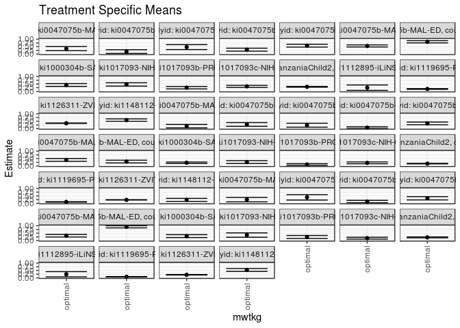

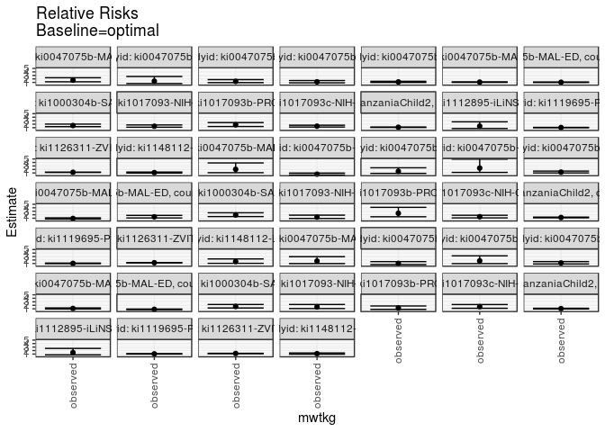

## Results Table

### Parameter: TSM

| agecat | studyid | country | intervention_level | baseline_level | estimate | ci_lower | ci_upper |
| --- | --- | --- | --- | --- | --- | --- | --- |
| 0-24 months | ki0047075b-MAL-ED | BANGLADESH | optimal | NA | 0.3697254 | 0.2315675 | 0.5078833 |
| 0-24 months | ki0047075b-MAL-ED | BRAZIL | optimal | NA | 0.1685835 | 0.0430704 | 0.2940966 |
| 0-24 months | ki0047075b-MAL-ED | INDIA | optimal | NA | 0.4689230 | 0.3026580 | 0.6351881 |
| 0-24 months | ki0047075b-MAL-ED | NEPAL | optimal | NA | 0.2980277 | 0.1987612 | 0.3972942 |
| 0-24 months | ki0047075b-MAL-ED | PERU | optimal | NA | 0.5662411 | 0.4707164 | 0.6617658 |
| 0-24 months | ki0047075b-MAL-ED | SOUTH AFRICA | optimal | NA | 0.5470140 | 0.4766923 | 0.6173357 |
| 0-24 months | ki0047075b-MAL-ED | TANZANIA, UNITED REPUBLIC OF | optimal | NA | 0.8283325 | 0.7529577 | 0.9037073 |
| 0-24 months | ki1000304b-SAS-CompFeed | INDIA | optimal | NA | 0.4282351 | 0.3341369 | 0.5223333 |
| 0-24 months | ki1017093-NIH-Birth | BANGLADESH | optimal | NA | 0.4695944 | 0.3557427 | 0.5834461 |
| 0-24 months | ki1017093b-PROVIDE | BANGLADESH | optimal | NA | 0.2487168 | 0.1679721 | 0.3294614 |
| 0-24 months | ki1017093c-NIH-Crypto | BANGLADESH | optimal | NA | 0.3374911 | 0.2683298 | 0.4066524 |
| 0-24 months | ki1066203-TanzaniaChild2 | TANZANIA, UNITED REPUBLIC OF | optimal | NA | 0.3085883 | 0.2840711 | 0.3331055 |
| 0-24 months | ki1112895-iLiNS-Zinc | BURKINA FASO | optimal | NA | 0.2484627 | 0.0654430 | 0.4314825 |
| 0-24 months | ki1119695-PROBIT | BELARUS | optimal | NA | 0.1630128 | 0.1409667 | 0.1850588 |
| 0-24 months | ki1126311-ZVITAMBO | ZIMBABWE | optimal | NA | 0.3676213 | 0.3549744 | 0.3802682 |
| 0-24 months | ki1148112-LCNI-5 | MALAWI | optimal | NA | 0.5790071 | 0.4971082 | 0.6609060 |
| 0-6 months | ki0047075b-MAL-ED | BANGLADESH | optimal | NA | 0.1701140 | 0.0551235 | 0.2851046 |
| 0-6 months | ki0047075b-MAL-ED | BRAZIL | optimal | NA | 0.2860917 | 0.1623935 | 0.4097899 |
| 0-6 months | ki0047075b-MAL-ED | INDIA | optimal | NA | 0.2340343 | 0.1023514 | 0.3657171 |
| 0-6 months | ki0047075b-MAL-ED | NEPAL | optimal | NA | 0.0718518 | 0.0148153 | 0.1288883 |
| 0-6 months | ki0047075b-MAL-ED | PERU | optimal | NA | 0.3562660 | 0.2654932 | 0.4470388 |
| 0-6 months | ki0047075b-MAL-ED | SOUTH AFRICA | optimal | NA | 0.4067155 | 0.3141421 | 0.4992890 |
| 0-6 months | ki0047075b-MAL-ED | TANZANIA, UNITED REPUBLIC OF | optimal | NA | 0.2980918 | 0.2050451 | 0.3911385 |
| 0-6 months | ki1000304b-SAS-CompFeed | INDIA | optimal | NA | 0.2178809 | 0.1672478 | 0.2685139 |
| 0-6 months | ki1017093-NIH-Birth | BANGLADESH | optimal | NA | 0.2629519 | 0.1665271 | 0.3593766 |
| 0-6 months | ki1017093b-PROVIDE | BANGLADESH | optimal | NA | 0.1018447 | 0.0451804 | 0.1585091 |
| 0-6 months | ki1017093c-NIH-Crypto | BANGLADESH | optimal | NA | 0.2120067 | 0.1509206 | 0.2730929 |
| 0-6 months | ki1066203-TanzaniaChild2 | TANZANIA, UNITED REPUBLIC OF | optimal | NA | 0.1608289 | 0.1419229 | 0.1797350 |
| 0-6 months | ki1119695-PROBIT | BELARUS | optimal | NA | 0.0933777 | 0.0788330 | 0.1079224 |
| 0-6 months | ki1126311-ZVITAMBO | ZIMBABWE | optimal | NA | 0.2303806 | 0.2192259 | 0.2415352 |
| 0-6 months | ki1148112-LCNI-5 | MALAWI | optimal | NA | 0.2296979 | 0.1295256 | 0.3298701 |
| 6-24 months | ki0047075b-MAL-ED | BANGLADESH | optimal | NA | 0.2479655 | 0.0987116 | 0.3972194 |
| 6-24 months | ki0047075b-MAL-ED | INDIA | optimal | NA | 0.4018319 | 0.2198470 | 0.5838167 |
| 6-24 months | ki0047075b-MAL-ED | NEPAL | optimal | NA | 0.1190466 | 0.0392834 | 0.1988099 |
| 6-24 months | ki0047075b-MAL-ED | PERU | optimal | NA | 0.3376334 | 0.2275395 | 0.4477274 |
| 6-24 months | ki0047075b-MAL-ED | SOUTH AFRICA | optimal | NA | 0.3283498 | 0.2435230 | 0.4131767 |
| 6-24 months | ki0047075b-MAL-ED | TANZANIA, UNITED REPUBLIC OF | optimal | NA | 0.9277978 | 0.8550881 | 1.0005074 |
| 6-24 months | ki1000304b-SAS-CompFeed | INDIA | optimal | NA | 0.3033394 | 0.2064085 | 0.4002704 |
| 6-24 months | ki1017093-NIH-Birth | BANGLADESH | optimal | NA | 0.3729039 | 0.2260401 | 0.5197678 |
| 6-24 months | ki1017093b-PROVIDE | BANGLADESH | optimal | NA | 0.2444364 | 0.1415893 | 0.3472836 |
| 6-24 months | ki1017093c-NIH-Crypto | BANGLADESH | optimal | NA | 0.1648937 | 0.1034110 | 0.2263764 |
| 6-24 months | ki1066203-TanzaniaChild2 | TANZANIA, UNITED REPUBLIC OF | optimal | NA | 0.2182131 | 0.1885551 | 0.2478711 |
| 6-24 months | ki1112895-iLiNS-Zinc | BURKINA FASO | optimal | NA | 0.2480696 | 0.0719729 | 0.4241664 |
| 6-24 months | ki1119695-PROBIT | BELARUS | optimal | NA | 0.0763155 | 0.0627917 | 0.0898393 |
| 6-24 months | ki1126311-ZVITAMBO | ZIMBABWE | optimal | NA | 0.2124026 | 0.1985722 | 0.2262330 |
| 6-24 months | ki1148112-LCNI-5 | MALAWI | optimal | NA | 0.5354457 | 0.4402393 | 0.6306520 |

### Parameter: E(Y)

| agecat | studyid | country | intervention_level | baseline_level | estimate | ci_lower | ci_upper |
| --- | --- | --- | --- | --- | --- | --- | --- |
| 0-24 months | ki0047075b-MAL-ED | BANGLADESH | observed | NA | 0.6102362 | 0.5501413 | 0.6703311 |
| 0-24 months | ki0047075b-MAL-ED | BRAZIL | observed | NA | 0.2262443 | 0.1709568 | 0.2815319 |
| 0-24 months | ki0047075b-MAL-ED | INDIA | observed | NA | 0.6074380 | 0.5457864 | 0.6690897 |
| 0-24 months | ki0047075b-MAL-ED | NEPAL | observed | NA | 0.3445378 | 0.2840363 | 0.4050393 |
| 0-24 months | ki0047075b-MAL-ED | PERU | observed | NA | 0.6413793 | 0.5860858 | 0.6966728 |
| 0-24 months | ki0047075b-MAL-ED | SOUTH AFRICA | observed | NA | 0.5888889 | 0.5300901 | 0.6476877 |
| 0-24 months | ki0047075b-MAL-ED | TANZANIA, UNITED REPUBLIC OF | observed | NA | 0.8593750 | 0.8167072 | 0.9020428 |
| 0-24 months | ki1000304b-SAS-CompFeed | INDIA | observed | NA | 0.6908851 | 0.6500577 | 0.7317124 |
| 0-24 months | ki1017093-NIH-Birth | BANGLADESH | observed | NA | 0.6645469 | 0.6276196 | 0.7014742 |
| 0-24 months | ki1017093b-PROVIDE | BANGLADESH | observed | NA | 0.4514200 | 0.4136828 | 0.4891573 |
| 0-24 months | ki1017093c-NIH-Crypto | BANGLADESH | observed | NA | 0.4794702 | 0.4438115 | 0.5151289 |
| 0-24 months | ki1066203-TanzaniaChild2 | TANZANIA, UNITED REPUBLIC OF | observed | NA | 0.3465136 | 0.3272783 | 0.3657490 |
| 0-24 months | ki1112895-iLiNS-Zinc | BURKINA FASO | observed | NA | 0.3559962 | 0.3060347 | 0.4059578 |
| 0-24 months | ki1119695-PROBIT | BELARUS | observed | NA | 0.1694743 | 0.1504830 | 0.1884655 |
| 0-24 months | ki1126311-ZVITAMBO | ZIMBABWE | observed | NA | 0.4356480 | 0.4264663 | 0.4448297 |
| 0-24 months | ki1148112-LCNI-5 | MALAWI | observed | NA | 0.6360382 | 0.6034429 | 0.6686335 |
| 0-6 months | ki0047075b-MAL-ED | BANGLADESH | observed | NA | 0.3464567 | 0.2878227 | 0.4050907 |
| 0-6 months | ki0047075b-MAL-ED | BRAZIL | observed | NA | 0.1855204 | 0.1341547 | 0.2368860 |
| 0-6 months | ki0047075b-MAL-ED | INDIA | observed | NA | 0.3429752 | 0.2830428 | 0.4029076 |
| 0-6 months | ki0047075b-MAL-ED | NEPAL | observed | NA | 0.1722689 | 0.1241936 | 0.2203442 |
| 0-6 months | ki0047075b-MAL-ED | PERU | observed | NA | 0.4413793 | 0.3841309 | 0.4986278 |
| 0-6 months | ki0047075b-MAL-ED | SOUTH AFRICA | observed | NA | 0.3814815 | 0.3234338 | 0.4395292 |
| 0-6 months | ki0047075b-MAL-ED | TANZANIA, UNITED REPUBLIC OF | observed | NA | 0.4179688 | 0.3574314 | 0.4785061 |
| 0-6 months | ki1000304b-SAS-CompFeed | INDIA | observed | NA | 0.4228987 | 0.3938571 | 0.4519404 |
| 0-6 months | ki1017093-NIH-Birth | BANGLADESH | observed | NA | 0.3497615 | 0.3124631 | 0.3870600 |
| 0-6 months | ki1017093b-PROVIDE | BANGLADESH | observed | NA | 0.2466368 | 0.2139486 | 0.2793250 |
| 0-6 months | ki1017093c-NIH-Crypto | BANGLADESH | observed | NA | 0.3033113 | 0.2704998 | 0.3361228 |
| 0-6 months | ki1066203-TanzaniaChild2 | TANZANIA, UNITED REPUBLIC OF | observed | NA | 0.1943027 | 0.1783091 | 0.2102964 |
| 0-6 months | ki1119695-PROBIT | BELARUS | observed | NA | 0.0970084 | 0.0840167 | 0.1100001 |
| 0-6 months | ki1126311-ZVITAMBO | ZIMBABWE | observed | NA | 0.2815517 | 0.2732174 | 0.2898859 |
| 0-6 months | ki1148112-LCNI-5 | MALAWI | observed | NA | 0.3579336 | 0.3007518 | 0.4151153 |
| 6-24 months | ki0047075b-MAL-ED | BANGLADESH | observed | NA | 0.4213836 | 0.3443902 | 0.4983771 |
| 6-24 months | ki0047075b-MAL-ED | INDIA | observed | NA | 0.4129032 | 0.3351414 | 0.4906651 |
| 6-24 months | ki0047075b-MAL-ED | NEPAL | observed | NA | 0.2102564 | 0.1529155 | 0.2675974 |
| 6-24 months | ki0047075b-MAL-ED | PERU | observed | NA | 0.3918919 | 0.3129763 | 0.4708075 |
| 6-24 months | ki0047075b-MAL-ED | SOUTH AFRICA | observed | NA | 0.3589744 | 0.2834562 | 0.4344926 |
| 6-24 months | ki0047075b-MAL-ED | TANZANIA, UNITED REPUBLIC OF | observed | NA | 0.7793103 | 0.7115754 | 0.8470453 |
| 6-24 months | ki1000304b-SAS-CompFeed | INDIA | observed | NA | 0.5024691 | 0.4579693 | 0.5469690 |
| 6-24 months | ki1017093-NIH-Birth | BANGLADESH | observed | NA | 0.5739130 | 0.5216565 | 0.6261696 |
| 6-24 months | ki1017093b-PROVIDE | BANGLADESH | observed | NA | 0.2997812 | 0.2577294 | 0.3418330 |
| 6-24 months | ki1017093c-NIH-Crypto | BANGLADESH | observed | NA | 0.2628458 | 0.2244546 | 0.3012371 |
| 6-24 months | ki1066203-TanzaniaChild2 | TANZANIA, UNITED REPUBLIC OF | observed | NA | 0.2277354 | 0.2069978 | 0.2484730 |
| 6-24 months | ki1112895-iLiNS-Zinc | BURKINA FASO | observed | NA | 0.3559962 | 0.3060347 | 0.4059578 |
| 6-24 months | ki1119695-PROBIT | BELARUS | observed | NA | 0.0803025 | 0.0658938 | 0.0947113 |
| 6-24 months | ki1126311-ZVITAMBO | ZIMBABWE | observed | NA | 0.2460554 | 0.2359900 | 0.2561209 |
| 6-24 months | ki1148112-LCNI-5 | MALAWI | observed | NA | 0.5989011 | 0.5632737 | 0.6345285 |

### Parameter: RR

| agecat | studyid | country | intervention_level | baseline_level | estimate | ci_lower | ci_upper |
| --- | --- | --- | --- | --- | --- | --- | --- |
| 0-24 months | ki0047075b-MAL-ED | BANGLADESH | observed | optimal | 1.6505120 | 1.1667677 | 2.3348177 |
| 0-24 months | ki0047075b-MAL-ED | BRAZIL | observed | optimal | 1.3420314 | 0.6693552 | 2.6907212 |
| 0-24 months | ki0047075b-MAL-ED | INDIA | observed | optimal | 1.2953896 | 0.9349164 | 1.7948494 |
| 0-24 months | ki0047075b-MAL-ED | NEPAL | observed | optimal | 1.1560597 | 0.8755711 | 1.5264026 |
| 0-24 months | ki0047075b-MAL-ED | PERU | observed | optimal | 1.1326966 | 0.9885727 | 1.2978322 |
| 0-24 months | ki0047075b-MAL-ED | SOUTH AFRICA | observed | optimal | 1.0765518 | 1.0068532 | 1.1510752 |
| 0-24 months | ki0047075b-MAL-ED | TANZANIA, UNITED REPUBLIC OF | observed | optimal | 1.0374759 | 0.9689845 | 1.1108086 |
| 0-24 months | ki1000304b-SAS-CompFeed | INDIA | observed | optimal | 1.6133314 | 1.2911887 | 2.0158464 |
| 0-24 months | ki1017093-NIH-Birth | BANGLADESH | observed | optimal | 1.4151508 | 1.1270384 | 1.7769153 |
| 0-24 months | ki1017093b-PROVIDE | BANGLADESH | observed | optimal | 1.8149964 | 1.3387360 | 2.4606883 |
| 0-24 months | ki1017093c-NIH-Crypto | BANGLADESH | observed | optimal | 1.4206899 | 1.1836790 | 1.7051581 |
| 0-24 months | ki1066203-TanzaniaChild2 | TANZANIA, UNITED REPUBLIC OF | observed | optimal | 1.1228995 | 1.0644233 | 1.1845883 |
| 0-24 months | ki1112895-iLiNS-Zinc | BURKINA FASO | observed | optimal | 1.4327952 | 0.7662937 | 2.6790017 |
| 0-24 months | ki1119695-PROBIT | BELARUS | observed | optimal | 1.0396383 | 0.9943033 | 1.0870402 |
| 0-24 months | ki1126311-ZVITAMBO | ZIMBABWE | observed | optimal | 1.1850457 | 1.1555704 | 1.2152728 |
| 0-24 months | ki1148112-LCNI-5 | MALAWI | observed | optimal | 1.0984981 | 0.9645795 | 1.2510094 |
| 0-6 months | ki0047075b-MAL-ED | BANGLADESH | observed | optimal | 2.0366143 | 1.0724028 | 3.8677610 |
| 0-6 months | ki0047075b-MAL-ED | BRAZIL | observed | optimal | 0.6484646 | 0.4349773 | 0.9667318 |
| 0-6 months | ki0047075b-MAL-ED | INDIA | observed | optimal | 1.4654914 | 0.8684319 | 2.4730379 |
| 0-6 months | ki0047075b-MAL-ED | NEPAL | observed | optimal | 2.3975587 | 1.1586876 | 4.9610333 |
| 0-6 months | ki0047075b-MAL-ED | PERU | observed | optimal | 1.2389038 | 1.0022645 | 1.5314149 |
| 0-6 months | ki0047075b-MAL-ED | SOUTH AFRICA | observed | optimal | 0.9379565 | 0.7949218 | 1.1067282 |
| 0-6 months | ki0047075b-MAL-ED | TANZANIA, UNITED REPUBLIC OF | observed | optimal | 1.4021477 | 1.0821779 | 1.8167237 |
| 0-6 months | ki1000304b-SAS-CompFeed | INDIA | observed | optimal | 1.9409631 | 1.4722408 | 2.5589142 |
| 0-6 months | ki1017093-NIH-Birth | BANGLADESH | observed | optimal | 1.3301352 | 0.9422536 | 1.8776894 |
| 0-6 months | ki1017093b-PROVIDE | BANGLADESH | observed | optimal | 2.4216941 | 1.4214907 | 4.1256704 |
| 0-6 months | ki1017093c-NIH-Crypto | BANGLADESH | observed | optimal | 1.4306682 | 1.1014921 | 1.8582172 |
| 0-6 months | ki1066203-TanzaniaChild2 | TANZANIA, UNITED REPUBLIC OF | observed | optimal | 1.2081328 | 1.1145799 | 1.3095382 |
| 0-6 months | ki1119695-PROBIT | BELARUS | observed | optimal | 1.0388821 | 0.9602898 | 1.1239065 |
| 0-6 months | ki1126311-ZVITAMBO | ZIMBABWE | observed | optimal | 1.2221154 | 1.1780526 | 1.2678263 |
| 0-6 months | ki1148112-LCNI-5 | MALAWI | observed | optimal | 1.5582800 | 1.0532325 | 2.3055087 |
| 6-24 months | ki0047075b-MAL-ED | BANGLADESH | observed | optimal | 1.6993639 | 0.9780962 | 2.9525088 |
| 6-24 months | ki0047075b-MAL-ED | INDIA | observed | optimal | 1.0275522 | 0.6859161 | 1.5393481 |
| 6-24 months | ki0047075b-MAL-ED | NEPAL | observed | optimal | 1.7661686 | 0.9750571 | 3.1991475 |
| 6-24 months | ki0047075b-MAL-ED | PERU | observed | optimal | 1.1607023 | 0.8708919 | 1.5469540 |
| 6-24 months | ki0047075b-MAL-ED | SOUTH AFRICA | observed | optimal | 1.0932680 | 0.9557393 | 1.2505868 |
| 6-24 months | ki0047075b-MAL-ED | TANZANIA, UNITED REPUBLIC OF | observed | optimal | 0.8399571 | 0.7647776 | 0.9225270 |
| 6-24 months | ki1000304b-SAS-CompFeed | INDIA | observed | optimal | 1.6564585 | 1.2288176 | 2.2329226 |
| 6-24 months | ki1017093-NIH-Birth | BANGLADESH | observed | optimal | 1.5390372 | 1.0619447 | 2.2304696 |
| 6-24 months | ki1017093b-PROVIDE | BANGLADESH | observed | optimal | 1.2264178 | 0.8311389 | 1.8096863 |
| 6-24 months | ki1017093c-NIH-Crypto | BANGLADESH | observed | optimal | 1.5940321 | 1.1439279 | 2.2212399 |
| 6-24 months | ki1066203-TanzaniaChild2 | TANZANIA, UNITED REPUBLIC OF | observed | optimal | 1.0436375 | 0.9445659 | 1.1531003 |
| 6-24 months | ki1112895-iLiNS-Zinc | BURKINA FASO | observed | optimal | 1.4350656 | 0.7882339 | 2.6126932 |
| 6-24 months | ki1119695-PROBIT | BELARUS | observed | optimal | 1.0522437 | 0.9886132 | 1.1199697 |
| 6-24 months | ki1126311-ZVITAMBO | ZIMBABWE | observed | optimal | 1.1584390 | 1.1028553 | 1.2168242 |
| 6-24 months | ki1148112-LCNI-5 | MALAWI | observed | optimal | 1.1185095 | 0.9517393 | 1.3145023 |

### Parameter: PAR

| agecat | studyid | country | intervention_level | baseline_level | estimate | ci_lower | ci_upper |
| --- | --- | --- | --- | --- | --- | --- | --- |
| 0-24 months | ki0047075b-MAL-ED | BANGLADESH | optimal | NA | 0.2405108 | 0.1134300 | 0.3675917 |
| 0-24 months | ki0047075b-MAL-ED | BRAZIL | optimal | NA | 0.0576608 | -0.0600127 | 0.1753344 |
| 0-24 months | ki0047075b-MAL-ED | INDIA | optimal | NA | 0.1385150 | -0.0131200 | 0.2901499 |
| 0-24 months | ki0047075b-MAL-ED | NEPAL | optimal | NA | 0.0465101 | -0.0364723 | 0.1294926 |
| 0-24 months | ki0047075b-MAL-ED | PERU | optimal | NA | 0.0751382 | -0.0015033 | 0.1517798 |
| 0-24 months | ki0047075b-MAL-ED | SOUTH AFRICA | optimal | NA | 0.0418749 | 0.0056748 | 0.0780750 |
| 0-24 months | ki0047075b-MAL-ED | TANZANIA, UNITED REPUBLIC OF | optimal | NA | 0.0310425 | -0.0252895 | 0.0873745 |
| 0-24 months | ki1000304b-SAS-CompFeed | INDIA | optimal | NA | 0.2626500 | 0.1632454 | 0.3620546 |
| 0-24 months | ki1017093-NIH-Birth | BANGLADESH | optimal | NA | 0.1949525 | 0.0891674 | 0.3007376 |
| 0-24 months | ki1017093b-PROVIDE | BANGLADESH | optimal | NA | 0.2027033 | 0.1270300 | 0.2783765 |
| 0-24 months | ki1017093c-NIH-Crypto | BANGLADESH | optimal | NA | 0.1419791 | 0.0807038 | 0.2032544 |
| 0-24 months | ki1066203-TanzaniaChild2 | TANZANIA, UNITED REPUBLIC OF | optimal | NA | 0.0379254 | 0.0214188 | 0.0544319 |
| 0-24 months | ki1112895-iLiNS-Zinc | BURKINA FASO | optimal | NA | 0.1075335 | -0.0370309 | 0.2520979 |
| 0-24 months | ki1119695-PROBIT | BELARUS | optimal | NA | 0.0064615 | -0.0005673 | 0.0134904 |
| 0-24 months | ki1126311-ZVITAMBO | ZIMBABWE | optimal | NA | 0.0680267 | 0.0587981 | 0.0772554 |
| 0-24 months | ki1148112-LCNI-5 | MALAWI | optimal | NA | 0.0570311 | -0.0181954 | 0.1322576 |
| 0-6 months | ki0047075b-MAL-ED | BANGLADESH | optimal | NA | 0.1763426 | 0.0654900 | 0.2871953 |
| 0-6 months | ki0047075b-MAL-ED | BRAZIL | optimal | NA | -0.1005714 | -0.2119789 | 0.0108362 |
| 0-6 months | ki0047075b-MAL-ED | INDIA | optimal | NA | 0.1089409 | -0.0137224 | 0.2316043 |
| 0-6 months | ki0047075b-MAL-ED | NEPAL | optimal | NA | 0.1004171 | 0.0425748 | 0.1582594 |
| 0-6 months | ki0047075b-MAL-ED | PERU | optimal | NA | 0.0851133 | 0.0094262 | 0.1608005 |
| 0-6 months | ki0047075b-MAL-ED | SOUTH AFRICA | optimal | NA | -0.0252341 | -0.0927357 | 0.0422676 |
| 0-6 months | ki0047075b-MAL-ED | TANZANIA, UNITED REPUBLIC OF | optimal | NA | 0.1198769 | 0.0428760 | 0.1968779 |
| 0-6 months | ki1000304b-SAS-CompFeed | INDIA | optimal | NA | 0.2050179 | 0.1340545 | 0.2759812 |
| 0-6 months | ki1017093-NIH-Birth | BANGLADESH | optimal | NA | 0.0868097 | -0.0037852 | 0.1774045 |
| 0-6 months | ki1017093b-PROVIDE | BANGLADESH | optimal | NA | 0.1447920 | 0.0882944 | 0.2012897 |
| 0-6 months | ki1017093c-NIH-Crypto | BANGLADESH | optimal | NA | 0.0913045 | 0.0355060 | 0.1471031 |
| 0-6 months | ki1066203-TanzaniaChild2 | TANZANIA, UNITED REPUBLIC OF | optimal | NA | 0.0334738 | 0.0203333 | 0.0466143 |
| 0-6 months | ki1119695-PROBIT | BELARUS | optimal | NA | 0.0036307 | -0.0037278 | 0.0109892 |
| 0-6 months | ki1126311-ZVITAMBO | ZIMBABWE | optimal | NA | 0.0511711 | 0.0426593 | 0.0596828 |
| 0-6 months | ki1148112-LCNI-5 | MALAWI | optimal | NA | 0.1282357 | 0.0377648 | 0.2187067 |
| 6-24 months | ki0047075b-MAL-ED | BANGLADESH | optimal | NA | 0.1734181 | 0.0365076 | 0.3103286 |
| 6-24 months | ki0047075b-MAL-ED | INDIA | optimal | NA | 0.0110714 | -0.1512682 | 0.1734109 |
| 6-24 months | ki0047075b-MAL-ED | NEPAL | optimal | NA | 0.0912098 | 0.0178233 | 0.1645962 |
| 6-24 months | ki0047075b-MAL-ED | PERU | optimal | NA | 0.0542585 | -0.0449035 | 0.1534204 |
| 6-24 months | ki0047075b-MAL-ED | SOUTH AFRICA | optimal | NA | 0.0306245 | -0.0134871 | 0.0747362 |
| 6-24 months | ki0047075b-MAL-ED | TANZANIA, UNITED REPUBLIC OF | optimal | NA | -0.1484874 | -0.2280419 | -0.0689329 |
| 6-24 months | ki1000304b-SAS-CompFeed | INDIA | optimal | NA | 0.1991297 | 0.1085230 | 0.2897364 |
| 6-24 months | ki1017093-NIH-Birth | BANGLADESH | optimal | NA | 0.2010091 | 0.0639111 | 0.3381071 |
| 6-24 months | ki1017093b-PROVIDE | BANGLADESH | optimal | NA | 0.0553448 | -0.0396454 | 0.1503349 |
| 6-24 months | ki1017093c-NIH-Crypto | BANGLADESH | optimal | NA | 0.0979521 | 0.0424972 | 0.1534071 |
| 6-24 months | ki1066203-TanzaniaChild2 | TANZANIA, UNITED REPUBLIC OF | optimal | NA | 0.0095223 | -0.0122490 | 0.0312935 |
| 6-24 months | ki1112895-iLiNS-Zinc | BURKINA FASO | optimal | NA | 0.1079266 | -0.0298044 | 0.2456575 |
| 6-24 months | ki1119695-PROBIT | BELARUS | optimal | NA | 0.0039870 | -0.0009726 | 0.0089466 |
| 6-24 months | ki1126311-ZVITAMBO | ZIMBABWE | optimal | NA | 0.0336529 | 0.0231691 | 0.0441367 |
| 6-24 months | ki1148112-LCNI-5 | MALAWI | optimal | NA | 0.0634554 | -0.0226857 | 0.1495965 |

### Parameter: PAF

| agecat | studyid | country | intervention_level | baseline_level | estimate | ci_lower | ci_upper |
| --- | --- | --- | --- | --- | --- | --- | --- |
| 0-24 months | ki0047075b-MAL-ED | BANGLADESH | optimal | NA | 0.3941274 | 0.1429314 | 0.5717010 |
| 0-24 months | ki0047075b-MAL-ED | BRAZIL | optimal | NA | 0.2548610 | -0.4939751 | 0.6283524 |
| 0-24 months | ki0047075b-MAL-ED | INDIA | optimal | NA | 0.2280314 | -0.0696144 | 0.4428502 |
| 0-24 months | ki0047075b-MAL-ED | NEPAL | optimal | NA | 0.1349928 | -0.1421117 | 0.3448648 |
| 0-24 months | ki0047075b-MAL-ED | PERU | optimal | NA | 0.1171510 | -0.0115594 | 0.2294844 |
| 0-24 months | ki0047075b-MAL-ED | SOUTH AFRICA | optimal | NA | 0.0711083 | 0.0068065 | 0.1312470 |
| 0-24 months | ki0047075b-MAL-ED | TANZANIA, UNITED REPUBLIC OF | optimal | NA | 0.0361222 | -0.0320083 | 0.0997549 |
| 0-24 months | ki1000304b-SAS-CompFeed | INDIA | optimal | NA | 0.3801645 | 0.2255199 | 0.5039305 |
| 0-24 months | ki1017093-NIH-Birth | BANGLADESH | optimal | NA | 0.2933615 | 0.1127188 | 0.4372270 |
| 0-24 months | ki1017093b-PROVIDE | BANGLADESH | optimal | NA | 0.4490347 | 0.2530268 | 0.5936096 |
| 0-24 months | ki1017093c-NIH-Crypto | BANGLADESH | optimal | NA | 0.2961166 | 0.1551764 | 0.4135441 |
| 0-24 months | ki1066203-TanzaniaChild2 | TANZANIA, UNITED REPUBLIC OF | optimal | NA | 0.1094484 | 0.0605241 | 0.1558248 |
| 0-24 months | ki1112895-iLiNS-Zinc | BURKINA FASO | optimal | NA | 0.3020636 | -0.3049826 | 0.6267266 |
| 0-24 months | ki1119695-PROBIT | BELARUS | optimal | NA | 0.0381270 | -0.0057293 | 0.0800709 |
| 0-24 months | ki1126311-ZVITAMBO | ZIMBABWE | optimal | NA | 0.1561507 | 0.1346265 | 0.1771395 |
| 0-24 months | ki1148112-LCNI-5 | MALAWI | optimal | NA | 0.0896661 | -0.0367211 | 0.2006455 |
| 0-6 months | ki0047075b-MAL-ED | BANGLADESH | optimal | NA | 0.5089890 | 0.0675146 | 0.7414525 |
| 0-6 months | ki0047075b-MAL-ED | BRAZIL | optimal | NA | -0.5421042 | -1.2989707 | -0.0344130 |
| 0-6 months | ki0047075b-MAL-ED | INDIA | optimal | NA | 0.3176350 | -0.1515008 | 0.5956390 |
| 0-6 months | ki0047075b-MAL-ED | NEPAL | optimal | NA | 0.5829091 | 0.1369546 | 0.7984291 |
| 0-6 months | ki0047075b-MAL-ED | PERU | optimal | NA | 0.1928349 | 0.0022594 | 0.3470091 |
| 0-6 months | ki0047075b-MAL-ED | SOUTH AFRICA | optimal | NA | -0.0661476 | -0.2579855 | 0.0964358 |
| 0-6 months | ki0047075b-MAL-ED | TANZANIA, UNITED REPUBLIC OF | optimal | NA | 0.2868084 | 0.0759375 | 0.4495586 |
| 0-6 months | ki1000304b-SAS-CompFeed | INDIA | optimal | NA | 0.4847919 | 0.3207633 | 0.6092093 |
| 0-6 months | ki1017093-NIH-Birth | BANGLADESH | optimal | NA | 0.2481967 | -0.0612854 | 0.4674306 |
| 0-6 months | ki1017093b-PROVIDE | BANGLADESH | optimal | NA | 0.5870659 | 0.2965132 | 0.7576152 |
| 0-6 months | ki1017093c-NIH-Crypto | BANGLADESH | optimal | NA | 0.3010259 | 0.0921405 | 0.4618498 |
| 0-6 months | ki1066203-TanzaniaChild2 | TANZANIA, UNITED REPUBLIC OF | optimal | NA | 0.1722765 | 0.1028010 | 0.2363720 |
| 0-6 months | ki1119695-PROBIT | BELARUS | optimal | NA | 0.0374269 | -0.0413523 | 0.1102463 |
| 0-6 months | ki1126311-ZVITAMBO | ZIMBABWE | optimal | NA | 0.1817467 | 0.1511415 | 0.2112484 |
| 0-6 months | ki1148112-LCNI-5 | MALAWI | optimal | NA | 0.3582668 | 0.0505420 | 0.5662562 |
| 6-24 months | ki0047075b-MAL-ED | BANGLADESH | optimal | NA | 0.4115445 | -0.0223943 | 0.6613050 |
| 6-24 months | ki0047075b-MAL-ED | INDIA | optimal | NA | 0.0268135 | -0.4579043 | 0.3503743 |
| 6-24 months | ki0047075b-MAL-ED | NEPAL | optimal | NA | 0.4338026 | -0.0255810 | 0.6874167 |
| 6-24 months | ki0047075b-MAL-ED | PERU | optimal | NA | 0.1384526 | -0.1482481 | 0.3535684 |
| 6-24 months | ki0047075b-MAL-ED | SOUTH AFRICA | optimal | NA | 0.0853112 | -0.0463104 | 0.2003754 |
| 6-24 months | ki0047075b-MAL-ED | TANZANIA, UNITED REPUBLIC OF | optimal | NA | -0.1905369 | -0.3075697 | -0.0839791 |
| 6-24 months | ki1000304b-SAS-CompFeed | INDIA | optimal | NA | 0.3963024 | 0.1862096 | 0.5521565 |
| 6-24 months | ki1017093-NIH-Birth | BANGLADESH | optimal | NA | 0.3502431 | 0.0583314 | 0.5516639 |
| 6-24 months | ki1017093b-PROVIDE | BANGLADESH | optimal | NA | 0.1846172 | -0.2031684 | 0.4474180 |
| 6-24 months | ki1017093c-NIH-Crypto | BANGLADESH | optimal | NA | 0.3726601 | 0.1258190 | 0.5498010 |
| 6-24 months | ki1066203-TanzaniaChild2 | TANZANIA, UNITED REPUBLIC OF | optimal | NA | 0.0418129 | -0.0586874 | 0.1327728 |
| 6-24 months | ki1112895-iLiNS-Zinc | BURKINA FASO | optimal | NA | 0.3031677 | -0.2686590 | 0.6172532 |
| 6-24 months | ki1119695-PROBIT | BELARUS | optimal | NA | 0.0496498 | -0.0115179 | 0.1071187 |
| 6-24 months | ki1126311-ZVITAMBO | ZIMBABWE | optimal | NA | 0.1367694 | 0.0932627 | 0.1781886 |
| 6-24 months | ki1148112-LCNI-5 | MALAWI | optimal | NA | 0.1059531 | -0.0507078 | 0.2392558 |